# Task-5 Chromosome-Level Effects of MSL Knockdown in Drosophila S2 RNA-seq Data

Nursima Çalık

2026-10-19

## Import data

Files were imported and all used packages were gathered at first part of code.[1]

```r
library(plyr)
library(readr)
library(dplyr)
library(arsenal)
library(tidyverse)
library(SummarizedExperiment)
```

```r
library(ggplot2)
library(tibble)
library(datarium)
library(pheatmap)
library(RColorBrewer)
library(DESeq2)

counts <- read.delim("data/counts.tsv", sep = "\t")
genes <- read.delim("data/genes.tsv", sep = "\t")
samples <- read.delim("data/samples.tsv", sep = "\t")
tpms <- read.delim("data/tpms.tsv", sep = "\t")
```

## Examine Datasets

Datasets were examined and comparison was made by gene id between counts and tpms data. It was checked whether there were any negative values.All data was tidy and matched each other. Also, there was no minus value.[2,3]

```r
dim(counts)
```

```
## [1] 10990     7
```

```r
str(counts)
```

```
## 'data.frame':    10990 obs. of  7 variables:
##  $ flybase_gene_id: chr  "FBgn0025836" "FBgn0284435" "FBgn0025835" "FBgn0040373" ...
##  $ control_rep1   : int  8 1 1 18 206 21 119 28 0 102 ...
##  $ control_rep2   : int  5 1 0 20 200 19 114 16 0 94 ...
##  $ msl2_rep1      : int  4 0 0 47 178 9 70 9 0 93 ...
##  $ msl2_rep2      : int  6 2 1 36 200 9 88 10 0 102 ...
##  $ mof_rep1       : int  12 0 3 33 145 10 80 14 0 78 ...
##  $ mof_rep2       : int  17 1 0 34 222 16 118 11 1 96 ...
```

```r
anyNA(counts)
```

```
## [1] FALSE
```

```r
sum(duplicated(counts))
```

```
## [1] 0
```

```r
dim(genes)
```

```
## [1] 10990     6
```

```r
str(genes)
```

```
## 'data.frame':    10990 obs. of  6 variables:
##  $ flybase_gene_id: chr  "FBgn0025836" "FBgn0284435" "FBgn0025835" "FBgn0040373" ...
##  $ gene_name      : chr  "RhoGAP1A" "tyn" "CG17707" "CG3038" ...
##  $ chromosome     : chr  "X" "X" "X" "X" ...
##  $ start          : int  127449 140318 142731 243954 245978 254876 255674 258335 265724 268509 ...
##  $ end            : int  140340 200663 148426 245856 254650 255524 258469 263999 267028 279718 ...
##  $ gene_length    : int  6068 5691 3791 1838 7235 649 2110 1605 1196 6973 ...
```

```r
table(genes$chromosome)
```

```
##
##   2L   2R   3L   3R    X
## 2088 2240 2097 2706 1859
```

```r
anyNA(genes)
```

```
## [1] FALSE
```

```r
sum(duplicated(genes))
```

```
## [1] 0
```

```r
dim(samples)
```

```
## [1] 6 7
```

```r
str(samples)
```

```
## 'data.frame':    6 obs. of  7 variables:
##  $ sample_id       : chr  "control_rep1" "control_rep2" "msl2_rep1" "msl2_rep2" ...
##  $ condition       : chr  "control" "control" "msl2" "msl2" ...
##  $ replicate       : int  1 2 1 2 1 2
##  $ gsm_accession   : chr  "GSM410195" "GSM410196" "GSM410197" "GSM410198" ...
##  $ geo_sample_title: chr  "Drosophila-S2-RNAseq1" "Drosophila-S2-RNAseq2" "Drosophila-S2-msl2RNAi-RNAseq1" "Drosophila-S2-msl2RNAi-RNAseq2" ...
##  $ sra_experiment  : chr  "SRX016201" "SRX016202" "SRX016203" "SRX016204" ...
##  $ run_accessions  : chr  "SRR034820;SRR034819" "SRR034821;SRR034822" "SRR034823;SRR034824" "SRR034826;SRR034825" ...
```

```r
anyNA(samples)
```

```
## [1] FALSE
```

```r
sum(duplicated(samples))
```

```
## [1] 0
```

```r
dim(tpms)
```

```
## [1] 10990     7
```

```r
str(tpms)
```

```
## 'data.frame':    10990 obs. of  7 variables:
##  $ flybase_gene_id: chr  "FBgn0025836" "FBgn0284435" "FBgn0025835" "FBgn0040373" ...
##  $ control_rep1   : num  0.646 0.144 0.108 4.769 12.632 ...
##  $ control_rep2   : num  0.488 0.174 0 6.565 14.403 ...
##  $ msl2_rep1      : num  0.454 0 0 12.609 11.064 ...
##  $ msl2_rep2      : num  0.5659 0.1852 0.0952 8.034 10.5325 ...
##  $ mof_rep1       : num  1.237 0 0.375 9.662 10.017 ...
##  $ mof_rep2       : num  1.363 0.143 0 8.632 13.189 ...
```

```r
anyNA(tpms)
```

```
## [1] FALSE
```

```r
sum(duplicated(tpms))
```

```
## [1] 0
```

```r
comparedf(genes, counts, by = "flybase_gene_id")
```

```
## Compare Object
##
## Function Call:
## comparedf(x = genes, y = counts, by = "flybase_gene_id")
##
## Shared: 0 non-by variables and 10990 observations.
## Not shared: 11 variables and 0 observations.
##
## Differences found in 0/0 variables compared.
## 0 variables compared have non-identical attributes.
```

```r
comparedf(genes, tpms, by = "flybase_gene_id")
```

```
## Compare Object
##
## Function Call:
## comparedf(x = genes, y = tpms, by = "flybase_gene_id")
##
## Shared: 0 non-by variables and 10990 observations.
## Not shared: 11 variables and 0 observations.
##
## Differences found in 0/0 variables compared.
## 0 variables compared have non-identical attributes.
```

```r
sum(counts$control_rep1 < 0, counts$control_rep2 < 0, counts$msl2_rep1 < 0, counts$msl2_rep2<0, counts$mof_rep1 <0, counts$mof_rep2 < 0, na.rm = TRUE)
```

```
## [1] 0
```

```r
sum(tpms$control_rep1 < 0, tpms$control_rep2 < 0, tpms$msl2_rep1 < 0, tpms$msl2_rep2<0, tpms$mof_rep1 <0, tpms$mof_rep2 < 0, na.rm = TRUE)
```

```
## [1] 0
```

## Create SummarizedExperiment

Counts matrix was generated for creating SummarizedExperiment. Firstly id column was turn to row names then with “as.matrix” function counts recorded as matrix. This process was made for other datasets. In SummarizedExperimet, Counts and tpms were used for assay, genes was used for rowData and samples was used for colData. In addition id matches were checked and it was controlled whether there was missing rows.[4-6]

```r
counts <- counts%>% remove_rownames %>% column_to_rownames(var="flybase_gene_id")
str(counts)
```

```
## 'data.frame':    10990 obs. of  6 variables:
##  $ control_rep1: int  8 1 1 18 206 21 119 28 0 102 ...
##  $ control_rep2: int  5 1 0 20 200 19 114 16 0 94 ...
##  $ msl2_rep1   : int  4 0 0 47 178 9 70 9 0 93 ...
##  $ msl2_rep2   : int  6 2 1 36 200 9 88 10 0 102 ...
##  $ mof_rep1    : int  12 0 3 33 145 10 80 14 0 78 ...
##  $ mof_rep2    : int  17 1 0 34 222 16 118 11 1 96 ...
```

```r
counts <- as.matrix(counts)

tpms <- tpms%>% remove_rownames %>% column_to_rownames(var="flybase_gene_id")
str(tpms)
```

```
## 'data.frame':    10990 obs. of  6 variables:
##  $ control_rep1: num  0.646 0.144 0.108 4.769 12.632 ...
##  $ control_rep2: num  0.488 0.174 0 6.565 14.403 ...
##  $ msl2_rep1   : num  0.454 0 0 12.609 11.064 ...
##  $ msl2_rep2   : num  0.5659 0.1852 0.0952 8.034 10.5325 ...
##  $ mof_rep1    : num  1.237 0 0.375 9.662 10.017 ...
##  $ mof_rep2    : num  1.363 0.143 0 8.632 13.189 ...
```

```r
tpms <- as.matrix(tpms)

genes <- genes %>% remove_rownames %>% column_to_rownames(var = "flybase_gene_id")
samples <- samples %>% remove_rownames %>% column_to_rownames(var = "sample_id")

sum(rownames(counts) %in% rownames(tpms))
```

```
## [1] 10990
```

```r
sum(rownames(genes) %in% rownames(counts))
```

```
## [1] 10990
```

```r
se <- SummarizedExperiment(assays = list(counts = counts, tpms = tpms), rowData = genes, colData = samples)
```

## Heuristic Analysis

Tpms matrix was extracted from SummarizedExperiment. It was turned to data frame again and rendered longer for visualization. So all conditions were collected one column named condition. Box plot and jitter were used for plotting. In this part y axis values were turned log10(tpms + 1) because of wide range of tpms(+1 was used for calculating 0 values). Additionally density plot was used for distribution. when the box and density plot were analyzed , it can be said that there was similar results like medians or width of box at first look. Also Density plots overlapped considerably but clear command can not be made. Because these plots showed all genes distribution and it could not be understood how same genes changed at different conditions. Distribution could be similar when an expression of gene increased and another expression of gene decreased. So it can be said that general tpm distribution can be similar between conditions but it was not directly showed change of genes. [7-10] Another point was correlation. correlation matrix was created and it was used for heat map. The samples were not clearly clustered according to their conditions. Replicates of the same condition were not always the samples most similar to one another; some samples from different conditions had shown a closer resemblance.[11,12]

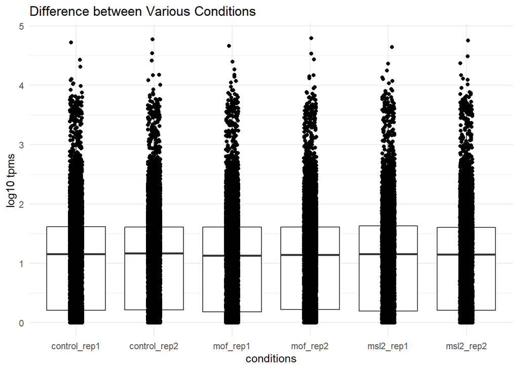

```r
tpms_plot <- assay(se, "tpms")
tpms_plot <- as.data.frame(tpms_plot)
tpms_plot <- tibble::rownames_to_column(tpms_plot, var = "flybase_gene_id")
tpms_longer <- pivot_longer(tpms_plot, cols = 2:7, names_to = "condition", values_to = "tpms")

ggplot(data = tpms_longer, mapping = aes(x = condition, y = log10(tpms+1)))+
  geom_boxplot(outlier.shape = NA)+
  geom_jitter(width = 0.08,
              height = 0)+
  labs(title = "Difference between Various Conditions", x = "conditions", y = "log10 tpms")+
  theme_minimal()
```

```r
aggregate(tpms ~ condition, data = tpms_longer, FUN = mean)
```

```
##      condition     tpms
## 1 control_rep1 82.74897
## 2 control_rep2 81.00697
## 3     mof_rep1 83.01290
## 4     mof_rep2 80.87846
## 5    msl2_rep1 83.48581
## 6    msl2_rep2 81.53406
```

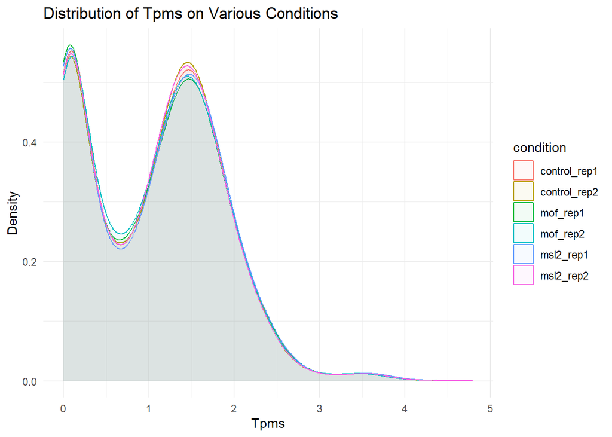

```r
ggplot(data = tpms_longer, mapping = aes(x=log10(tpms+1), colour = condition, fill = condition))+
  geom_density(bw = 0.2, alpha = 0.05)+
  labs(title = "Distribution of Tpms on Various Conditions ", x = "Tpms", y = "Density")+
  theme_minimal()
```

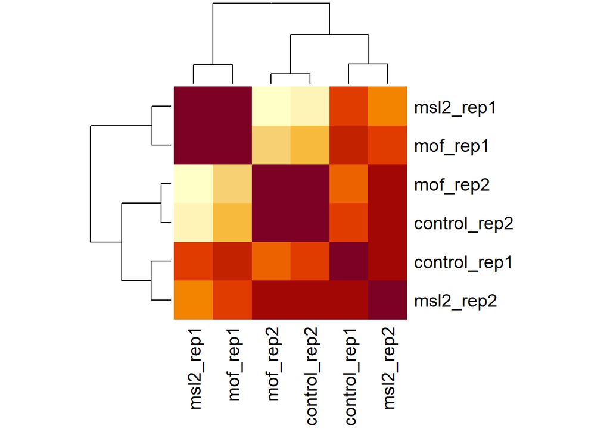

```r
tpms_cor <- assay(se, "tpms")
tpms_cor <- cor(tpms_cor)
HeatMap <- heatmap(tpms_cor, scale = "none", symm = TRUE, margins = c(8,8))
```